# Graafikud

Risto Hinno

jaanuar 2019

## Graafikutest

Graafikud on olulised vahendid info edastamiseks, hea graafikuga saab öelda rohkem, kui lehekülje tekstiga. Mõningaid mõtted hea graafiku tegemiseks:

- kasuta pealkirju, nii graafikul kui ka selle telgedel
- mida vähem tinti graafikule kulutad, seda parem
- üks graafik = üks sõnum
- väldi sektordiagramme, 3-d graafikuid
- inimesed suudavad visuaalselt eristada (tähtsuse järjekorras):
  - objektide positsioon skaala suhtes
  - pikkus
  - pindala
  - värviskaala

## Baasgraafikud

Kiiremaiks viisiks, kuidas saada andmetest ülevaade, on graafik. R-i puhul võib alustada baasgraafikutest, mis annavad lihtsad graafikud ilma erilist vaeva nägemata.

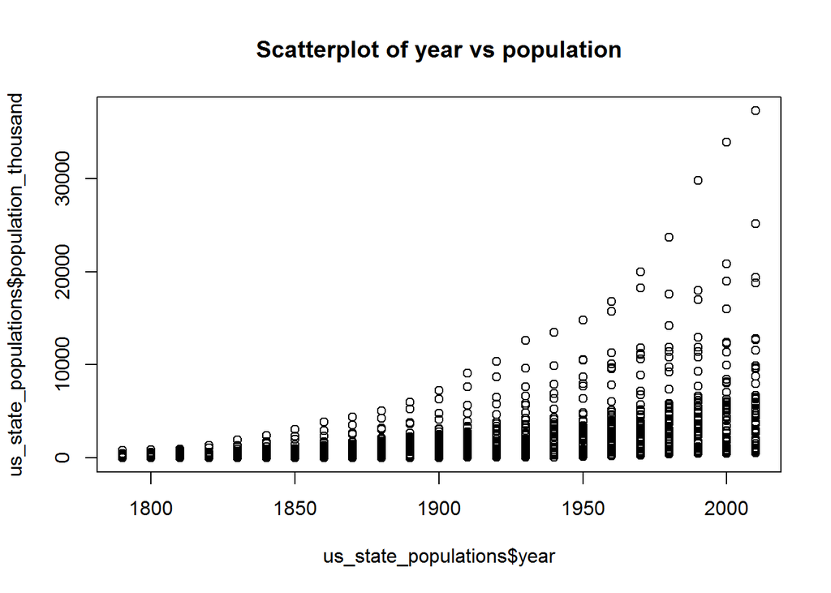

```r
#laeme andmed
#ise saad need siit: https://github.com/RRisto/RRisto.github.io/blob/master/r/data/introductory_state_example.csv
us_state_populations<-read.csv("data/introductory_state_example.csv")
us_state_populations$population_thousand=us_state_populations$population/1000


plot(us_state_populations$year,us_state_populations$population_thousand, main="Scatterplot of year vs population")
```

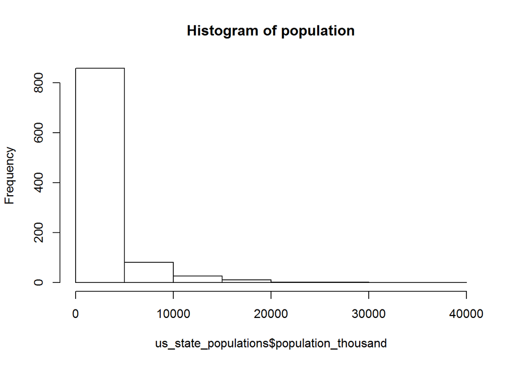

```r
hist(us_state_populations$population_thousand, main="Histogram of population")
```

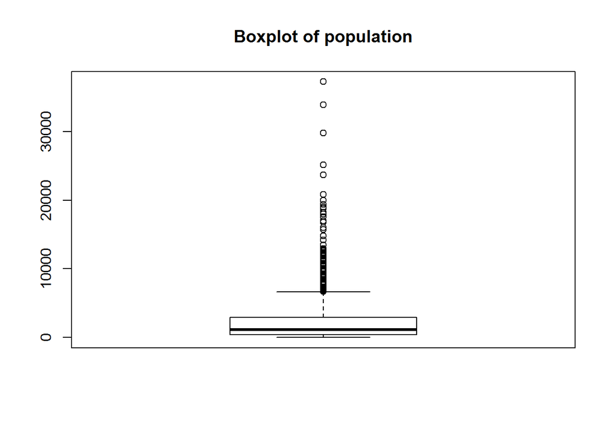

```r
boxplot(us_state_populations$population_thousand, main="Boxplot of population")
```

## Lattice

Lattice on üks pakett graafikute tegemiseks. Annab veidi ilusamaid graafikuid kui baasgraafikud. Kuid isiklikult ei kasuta peaaegu üldse. Siin on paar näidet.

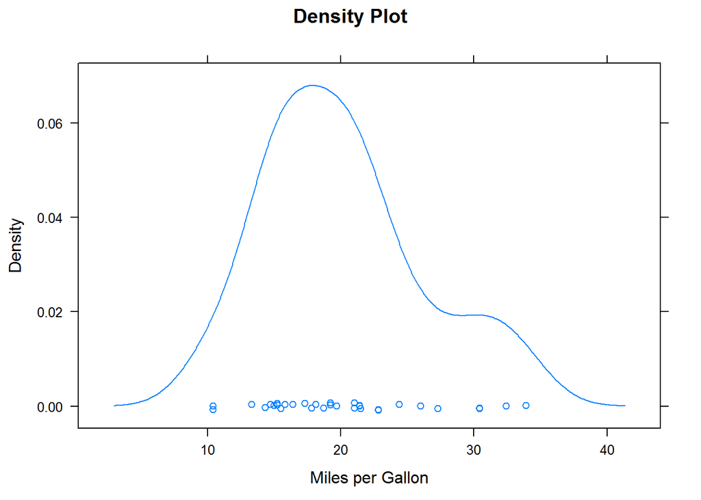

```r
library(lattice)
#võtame ühe Riga kaasas olnud andmehulga külge
attach(mtcars)

# muudame muutujad faktoriteks
gear.f<-factor(gear,levels=c(3,4,5),
    labels=c("3gears","4gears","5gears"))
cyl.f <-factor(cyl,levels=c(4,6,8),
   labels=c("4cyl","6cyl","8cyl"))

# kernel density plot
densityplot(~mpg,
    main="Density Plot",
    xlab="Miles per Gallon")
```

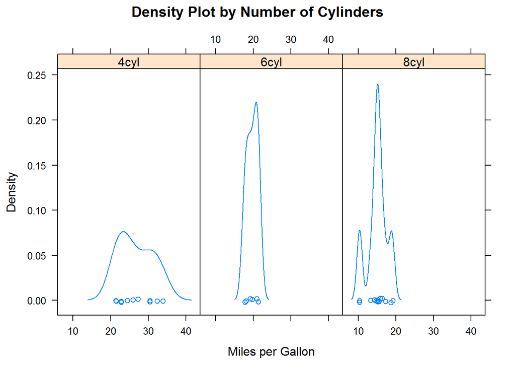

```r
# kernel density plots by factor level
densityplot(~mpg|cyl.f,
    main="Density Plot by Number of Cylinders",
   xlab="Miles per Gallon")
```

Rohkem näited lattice kohta: https://www.statmethods.net/advgraphs/trellis.html

## ggplot

Kõige populaarsem graafikute pakett on ggplot2. Tegemist on paketiga, mis on osa tidyversest. Selle kohta on ka head kokkuvõtlikud materjalid: https://www.rstudio.com/wp-content/uploads/2015/03/ggplot2-cheatsheet.pdf ja http://www.cookbook-r.com/Graphs/

ggplot on: “*ggplot2 is based on the grammar of graphics, the idea that you can build every graph from the same few components: a data set, a set of geoms—visual marks that represent data points, and a coordinate system.*”

Alustuseks mõned näited:

```r
library(tidyverse)
```

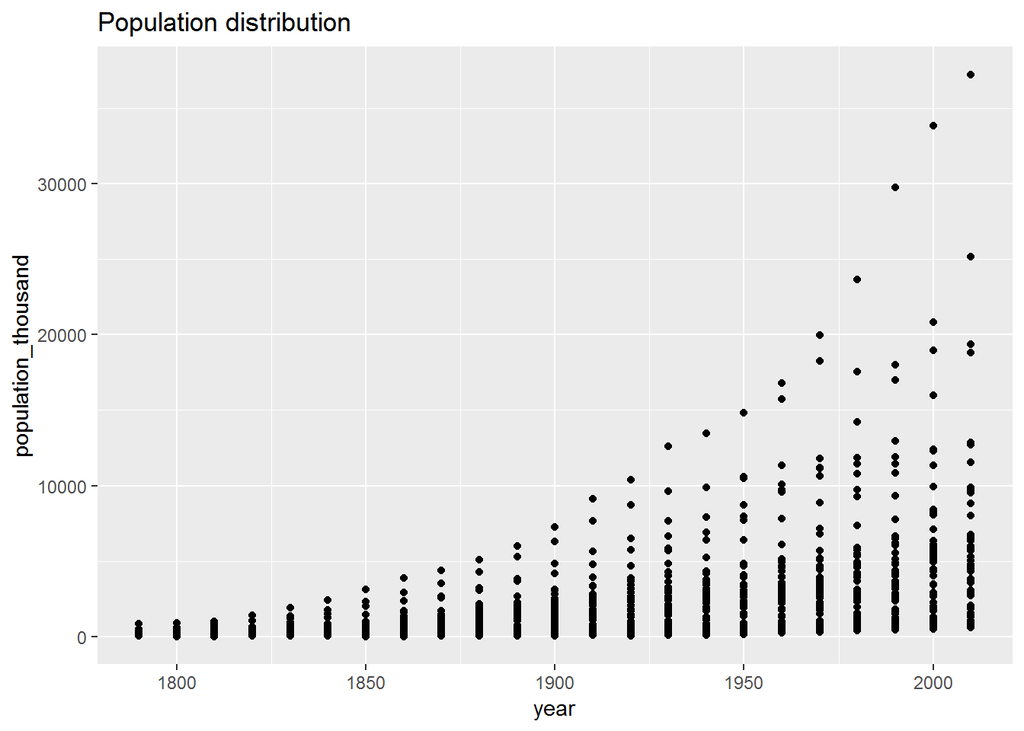

```r
#qplot on kiire viis kuidas saada vaikeväärtustega graafik
qplot(x = year, y = population_thousand, main="Population distribution", data = us_state_populations, geom = "point")
```

ggploti kogu jõu kasutamiseks tuleb kasutada ggploti funktsiooni:

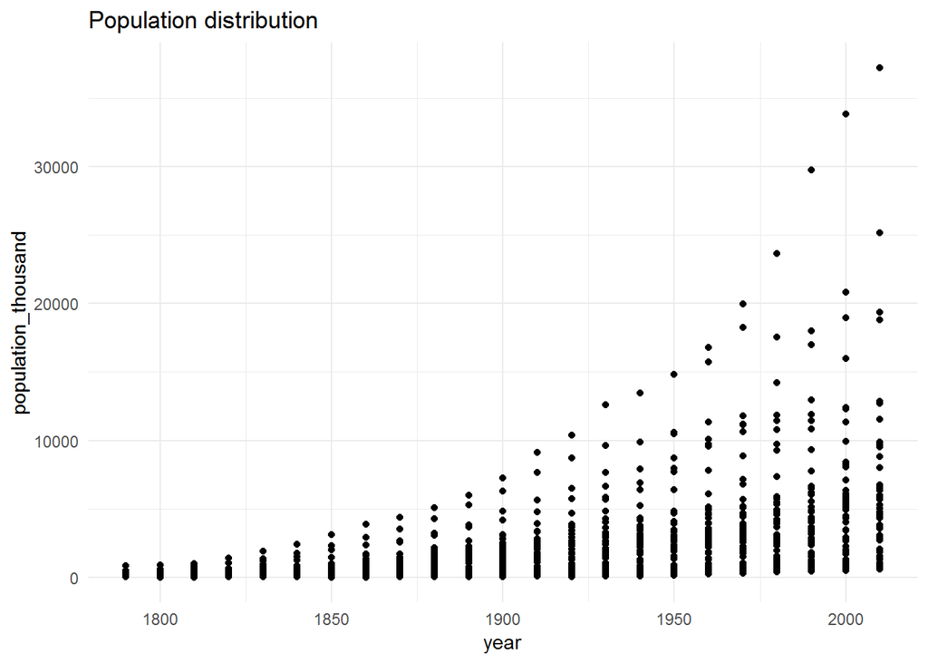

```r
#esimene argument on andmeraam, kõik muutujad, mis tulevad andmetest peab olema aes(...) sees
plt=ggplot(us_state_populations, aes(year, population_thousand))+
  #lisame geom kihi, antud juhul tahame punkte
  geom_point()+
  ggtitle("Population distribution")+
  theme_minimal()
plt
```

Ja nüüd saame siia kihte juurde lisada:

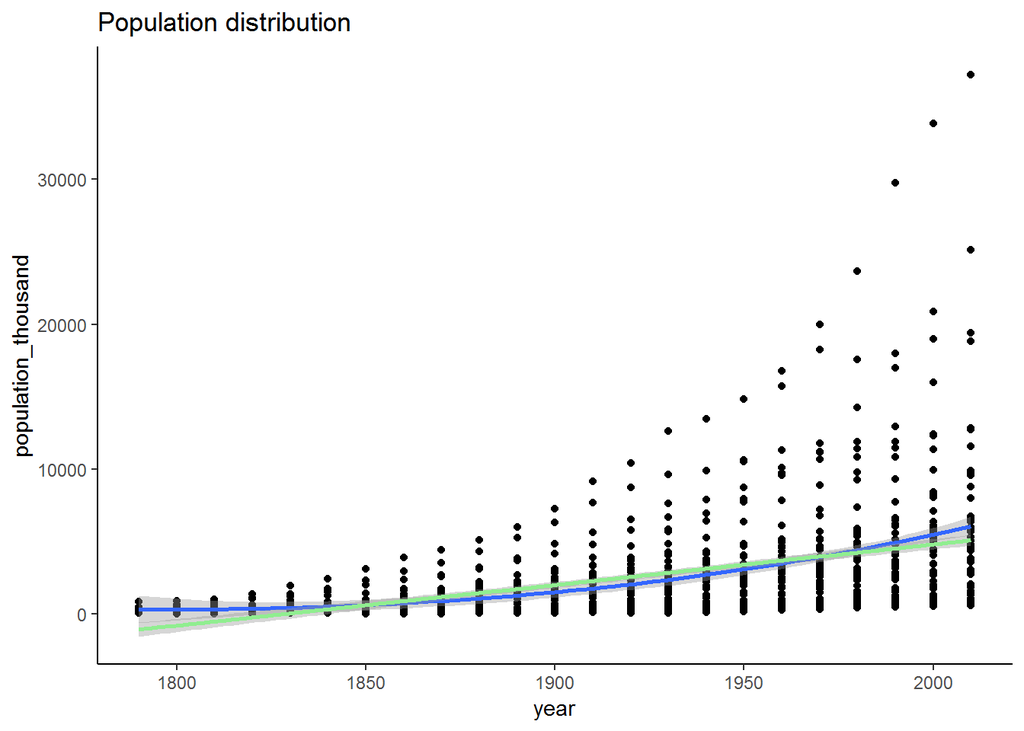

```r
#geom smooth lisab trendijoone (tehes mudeli võimaliku trendi kohta)
plt+geom_smooth()+
  #täpsustame regressiooni tüübi, tahame lineaarset regressiooni
  geom_smooth(method=lm, color='lightgreen')+
  theme_classic()
```

ggplotiga saab kõiki graafikul olevaid elemente muuta ja stiliseerida. See on üks põhjus, miks ggplot on populaarne.

Käesoleval juhul tundub, et punktid võivad olla üksteisega kaetud olla. Ajame nad veidi “laiali”.

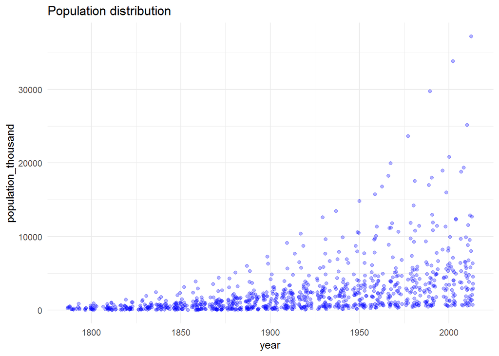

```r
ggplot(us_state_populations, aes(year, population_thousand))+
  #ajab punktid juhuslikkusega laiali, alpha määrab läbipaistvuse
  geom_jitter(alpha=0.3, color="blue")+
  ggtitle("Population distribution")+
  theme_minimal()
```

Veel mõningaid graafikutüüpe.

### Line plot

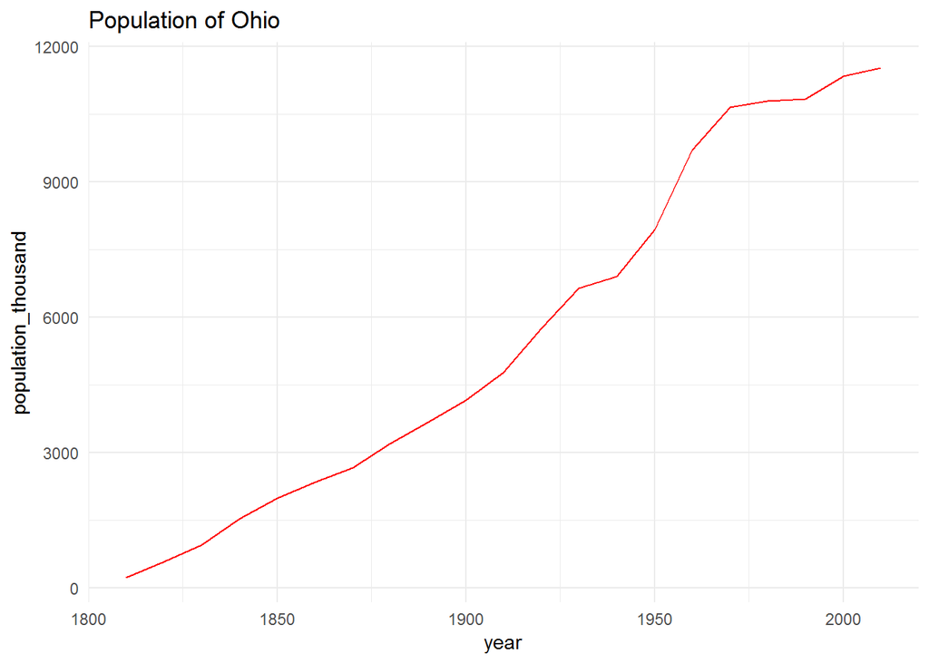

```r
#võtame ühe osariigi
df_ohio=us_state_populations[us_state_populations$state=="Ohio",]
#plotime
ggplot(df_ohio, aes(year, population_thousand))+
  geom_line(color="red")+
  ggtitle("Population of Ohio")+
  theme_minimal()
```

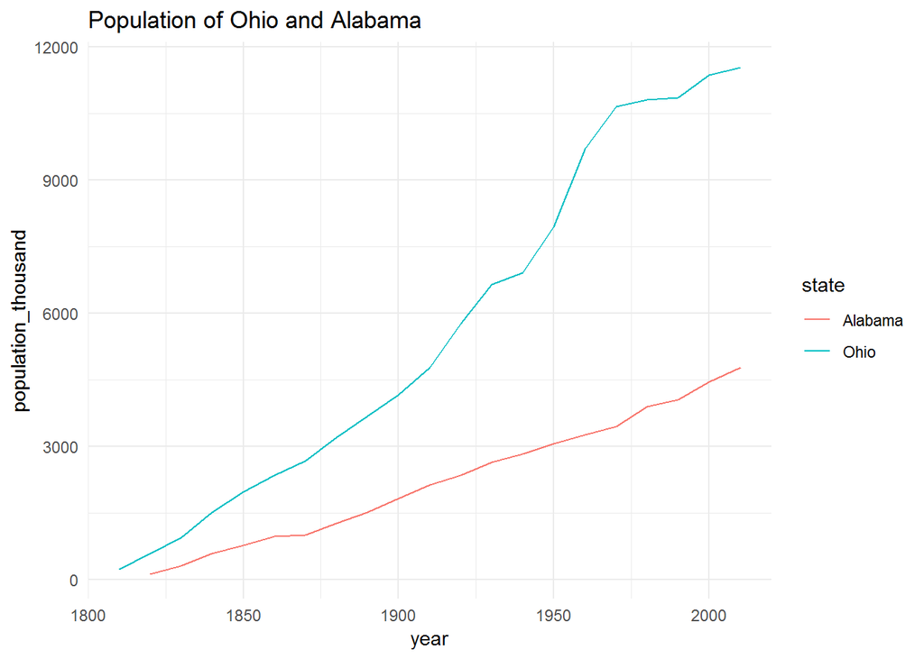

```r
df_ohio_alabama=us_state_populations[us_state_populations$state %in% c('Ohio', 'Alabama'),]

ggplot(df_ohio_alabama, aes(year, population_thousand))+
  geom_line(aes(group=state, color=state))+
  ggtitle("Population of Ohio and Alabama")+
  theme_minimal()
```

### Tulpdiagram

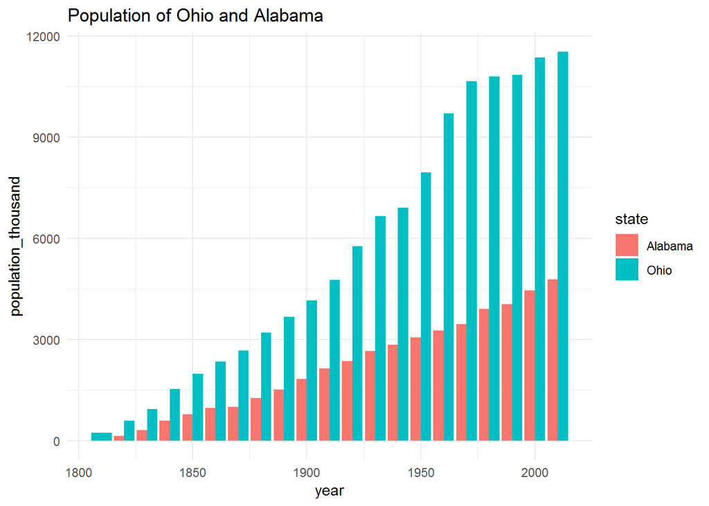

```r
ggplot(df_ohio_alabama, aes(year, population_thousand))+
  #stat=identity määrab, et näitab muutuja tegelikku väärtust, mitte counti
  #position_dodge() tõstab tulbad, üksteise kõrvale
  geom_bar(stat='identity', aes(fill=state), position=position_dodge())+
  ggtitle("Population of Ohio and Alabama")+
  theme_minimal()
```

Kui tahame kasutada ühte tulpa aasta kohta:

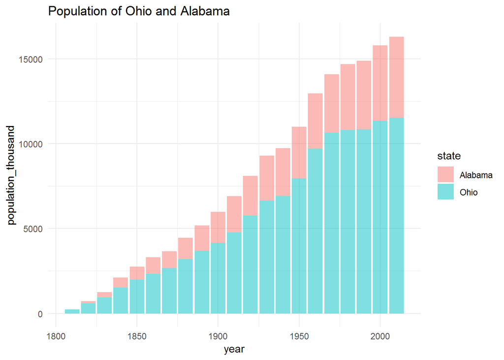

```r
ggplot(df_ohio_alabama, aes(year, population_thousand))+
  #stat=identity määra, et näitab muutuja tegelikku väärtust, mitte counti
  #alpha määrab läbipaistvuse
  geom_bar(stat='identity', aes(fill=state), alpha=0.5)+
  ggtitle("Population of Ohio and Alabama")+
  theme_minimal()
```

### Boxplot

Muutuja jaotuse visualiseerimiseks on hea kasutada boxploti:

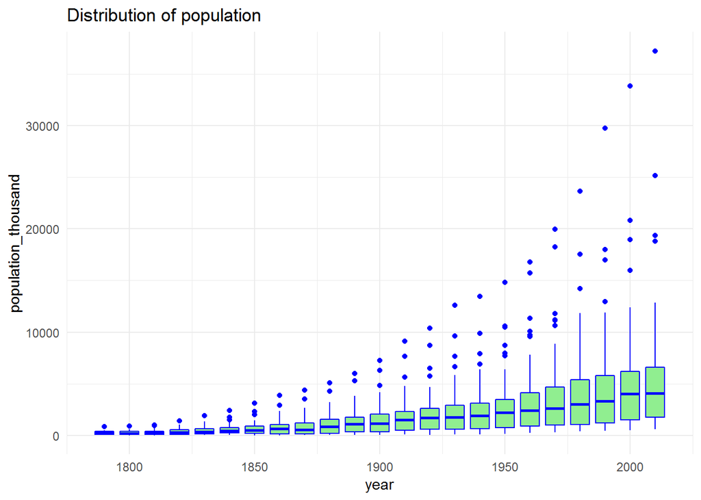

```r
ggplot(us_state_populations, aes(year, population_thousand, group=year))+
  geom_boxplot(fill='lightgreen', color='blue')+
  ggtitle("Distribution of population")+
  theme_minimal()
```

Boxploti lugemiseks ja mõistmiseks on hea kasutada alljärgnevat spikrit:

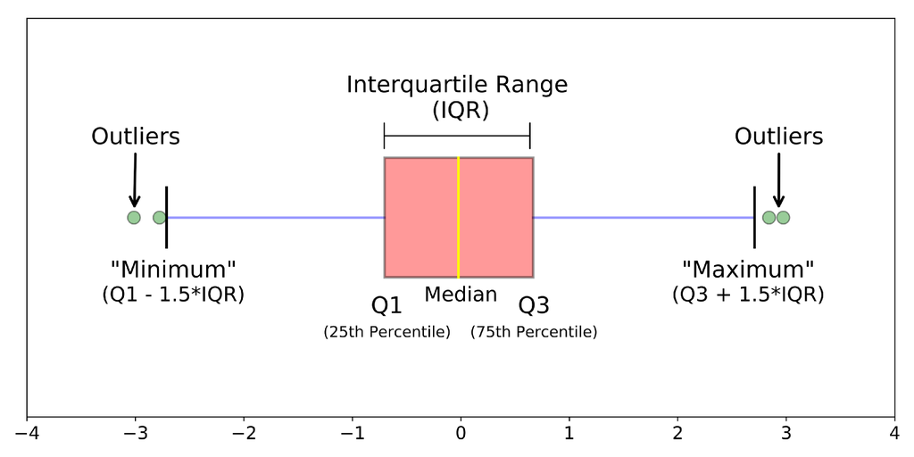

### Histogram

Histogrammiga saab vaadelda, kui palju mingis vahemikus muutujal väärtusi esineb:

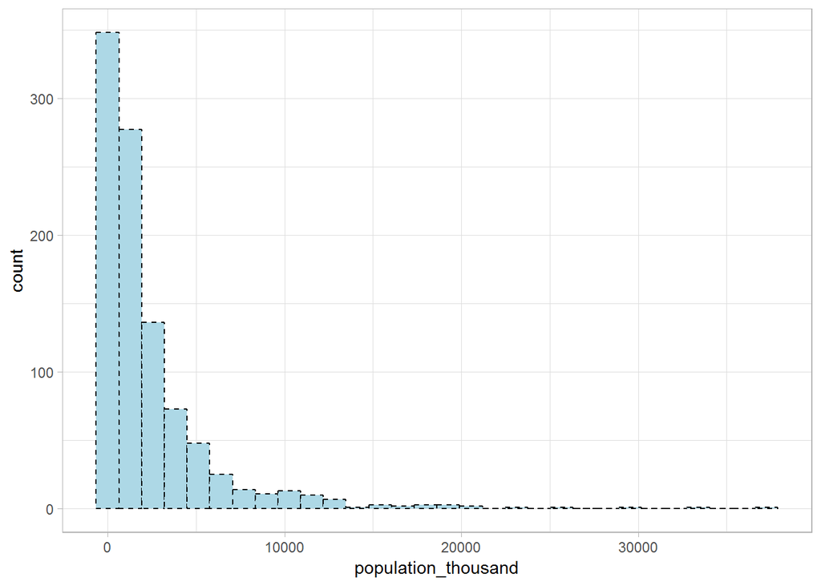

```r
ggplot(us_state_populations, aes(x=population_thousand))+
  geom_histogram(color="black", fill="lightblue", linetype="dashed")+
  theme_light()
```

### Density plot

Density plot on võrreldav histogrammiga, kuid on sujuvam. Samuti on väärtused normaliseeritud (st värvitud ala summa on 1).

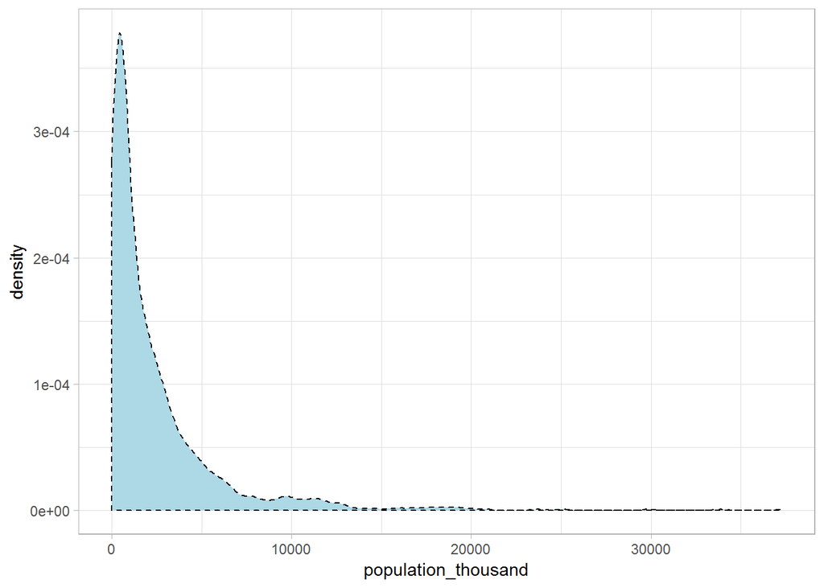

```r
ggplot(us_state_populations, aes(x=population_thousand))+
  geom_density(color="black", fill="lightblue", linetype="dashed")+
  theme_light()
```

### Facetid

See on väga kasulik vahend võrdlemaks muutujat dünaamikat mingites alamgruppides.

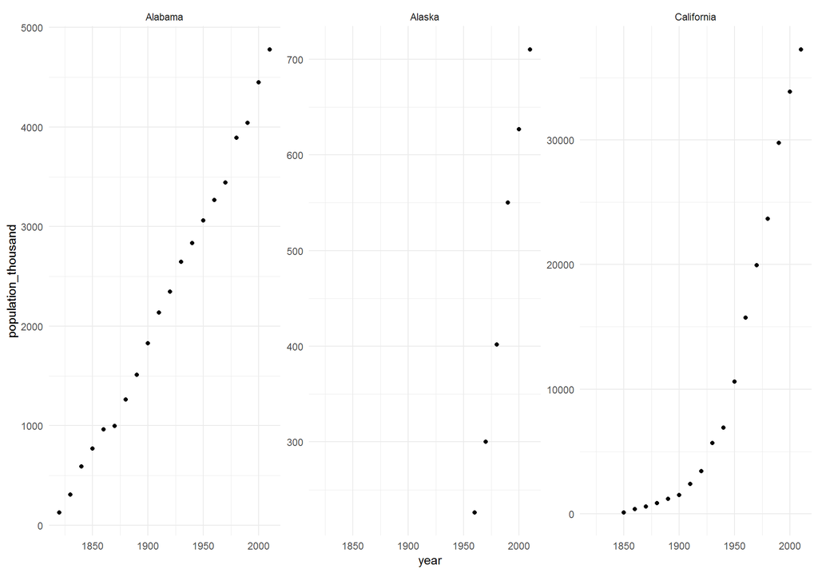

```r
alaska_alabama_california=us_state_populations[us_state_populations$state %in%
                                                 c("Alaska", "Alabama", "California"), ]
ggplot(alaska_alabama_california, aes(x=year, y=population_thousand))+
  geom_point()+
  facet_wrap(~state, ncol=3,scales = "free_y")+
  theme_minimal()
```

Sarnaselt töötab ka facet_grid:

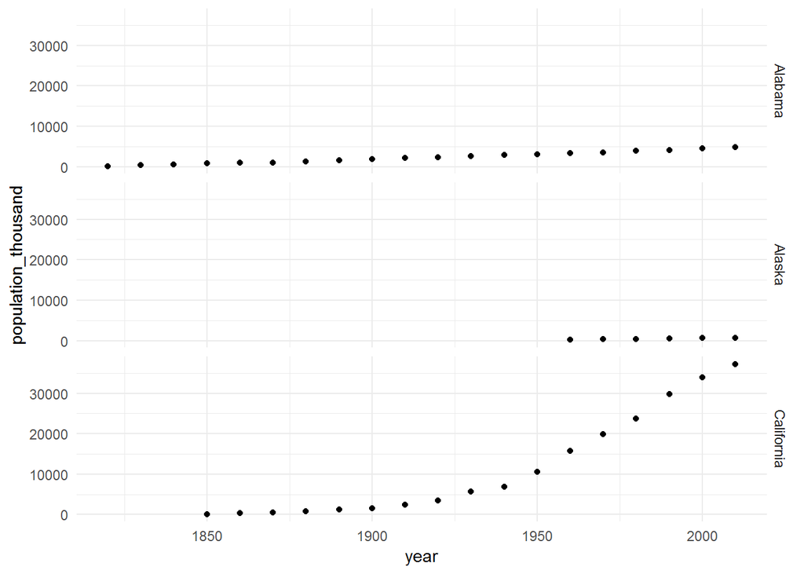

```r
ggplot(alaska_alabama_california, aes(x=year, y=population_thousand))+
  geom_point()+
  #kui rows asemel anda columns=... siis teeb veeru iga osariigi kohta
  #selle võib asendada ka facet_grid(.~ state) või facet_grid(state ~.)
  facet_grid(rows = vars(state))+
  theme_minimal()
```

Ja kui tahame kõiki kahe muutuja kombinatsioone vaadata:

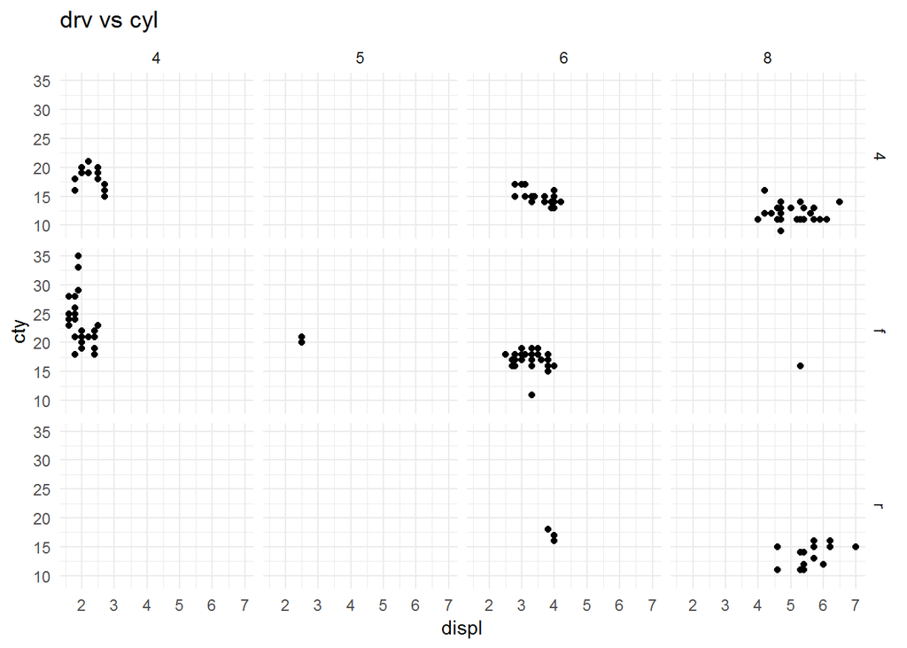

```r
data(mpg)#laeme Ris olemasoleva andmehulga
ggplot(mpg, aes(displ, cty)) +
  geom_point()+
  facet_grid(drv ~ cyl)+
  ggtitle("drv vs cyl")+
  theme_minimal()
```

### Tuunimine

ggplot on võimas, kuna võimaldab meil graafikut väga palju kohendada. Siin lihtsalt mõned näited. Rohkem infot ja abi leiad googlest ja http://www.cookbook-r.com/Graphs/

#### Usaldusintervallide lisamine

```r
#funktsioon usaldusintervallide arvutamiseks, laenatud siit http://www.cookbook-r.com/Graphs/Plotting_means_and_error_bars_(ggplot2)/
#ei ole oluline selle toimeloogiat mõista
summarySE <- function(data=NULL, measurevar, groupvars=NULL, na.rm=FALSE,
                      conf.interval=.95, .drop=TRUE) {
    library(plyr)

    # New version of length which can handle NA's: if na.rm==T, don't count them
    length2 <- function (x, na.rm=FALSE) {
        if (na.rm) sum(!is.na(x))
        else       length(x)
    }

    # This does the summary. For each group's data frame, return a vector with
    # N, mean, and sd
    datac <- ddply(data, groupvars, .drop=.drop,
      .fun = function(xx, col) {
        c(N    = length2(xx[[col]], na.rm=na.rm),
          mean = mean   (xx[[col]], na.rm=na.rm),
          sd   = sd     (xx[[col]], na.rm=na.rm)
        )
      },
      measurevar
    )

    # Rename the "mean" column
    datac <- rename(datac, c("mean" = measurevar))

    datac$se <- datac$sd / sqrt(datac$N)  # Calculate standard error of the mean

    # Confidence interval multiplier for standard error
    # Calculate t-statistic for confidence interval:
    # e.g., if conf.interval is .95, use .975 (above/below), and use df=N-1
    ciMult <- qt(conf.interval/2 + .5, datac$N-1)
    datac$ci <- datac$se * ciMult

    return(datac)
}
```

Arvutame usaldusintervallid:

```r
us_state_populations_se <- summarySE(us_state_populations, measurevar="population_thousand", groupvars=c("year"))
```

Ja paneme graafikule ning tuunime graafikut (NB! see graafik on lausa kole ning keelatud disainipolitsei poolt. Asja eesmärk on näidata mida ja kuidas muuta saab):

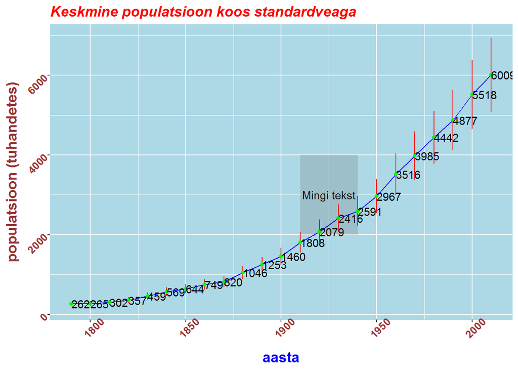

```r
ggplot(us_state_populations_se, aes(x=year, y=population_thousand)) +
  geom_errorbar(aes(ymin=population_thousand-se, ymax=population_thousand+se),
                  color="red", width=.1) +
  #joon
  geom_line(color="blue") +
  #punktid
  geom_point(color="green")+
  #lisame igale punktile ka selle väärtuse
  geom_text(aes(label=round(population_thousand,0)),hjust=0, vjust=0.5)+
  #pealkiri
  ggtitle("Keskmine populatsioon koos standardveaga")+
  #x-telje pealkiri
  xlab("aasta")+
  #y-telje pealkiri
  ylab("populatsioon (tuhandetes)")+
  #lisame teksti graafikule
  annotate("text", x = 1925, y = 3000, label = "Mingi tekst")+
  #lisame märgistatud ala
  annotate("rect", xmin = 1910, xmax = 1940, ymin = 2000, ymax = 4000, alpha = .2)+
  theme(
    #pealkirja muutmine
    plot.title = element_text(color="red", size=14, face="bold.italic"),
    #x-telje pealkirja muutmine
    axis.title.x = element_text(color="blue", size=14, face="bold"),
    #ytelje pealkirja muutmine
    axis.title.y = element_text(color="#993333", size=14, face="bold"),
    #x-telje elementide tekst
    axis.text.x = element_text(face="bold", color="#993333", size=10, angle=45),
     #y-telje elementide tekst
    axis.text.y = element_text(face="bold", color="#993333", size=10, angle=45),
    #tausta muutmine
     panel.background = element_rect(fill = "lightblue",colour = "lightblue",
                                     size = 0.5, linetype = "solid"),
    #peamine ruudustiku muutmine
    panel.grid.major = element_line(size = 0.5, linetype = 'solid',
                                    colour = "white"),
    #väikese ruudustiku muutmine
    panel.grid.minor = element_line(size = 0.25, linetype = 'solid',
                                    colour = "white"))
```

#### Skaala muutmine

Skaala muutmiseks on kihid xlim() ja ylim(). Nende miinuseks on, et skaalast välja jäänud väärtused asendatakse NA-ga.

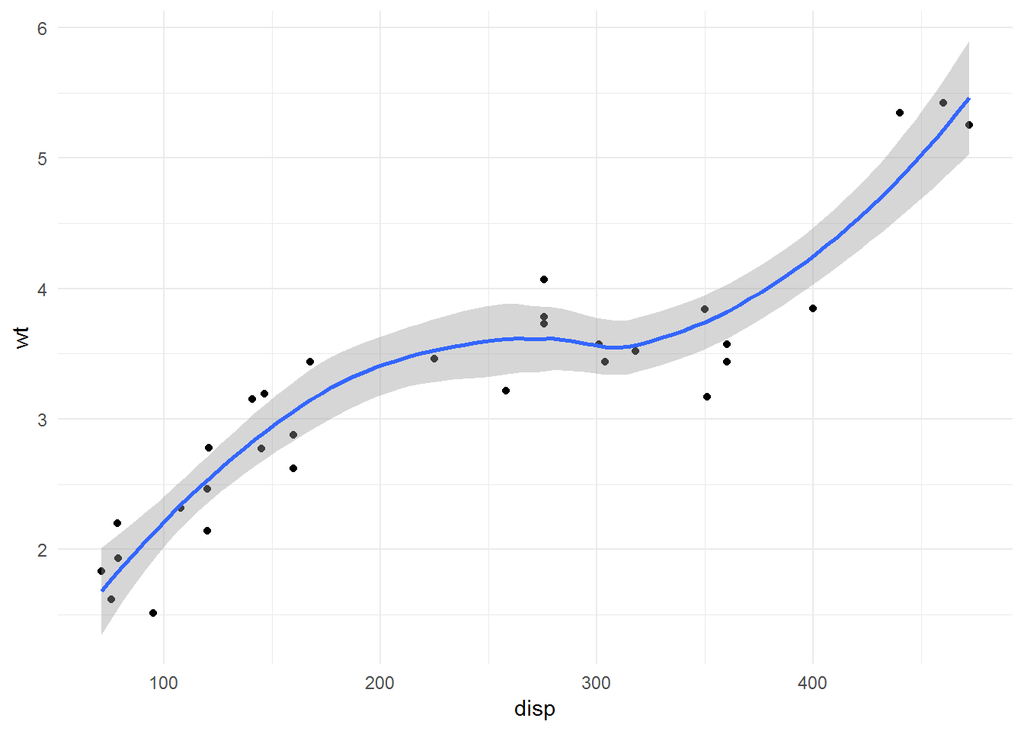

```r
p <- ggplot(mtcars, aes(disp, wt)) +
  geom_point() +
  geom_smooth()+
  theme_minimal()
p
```

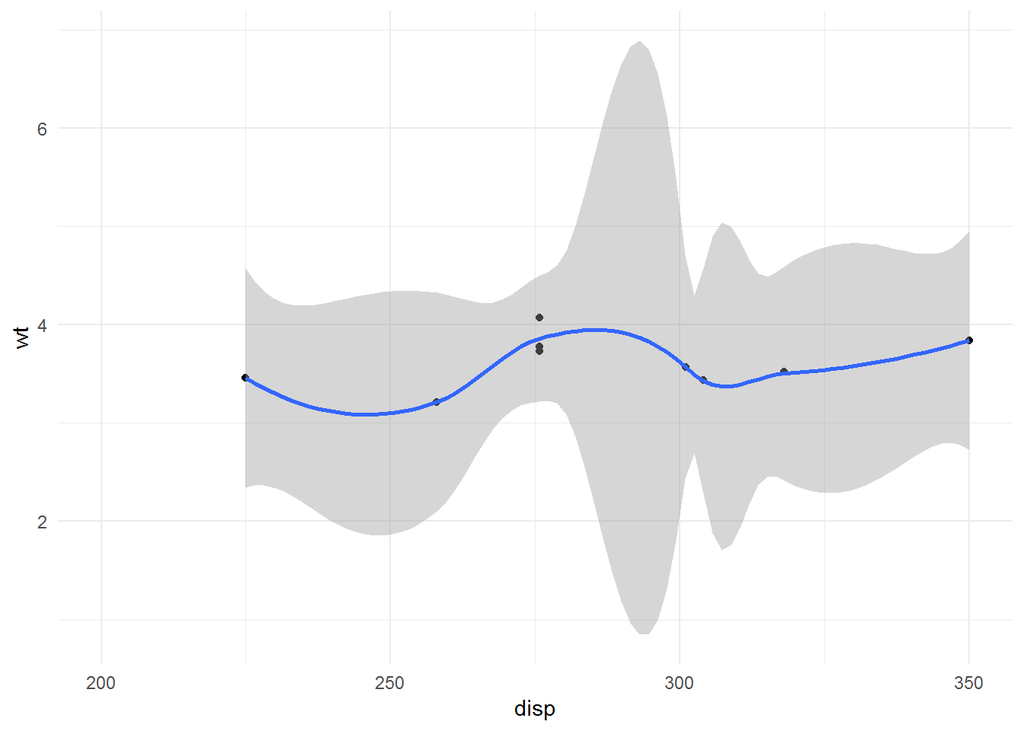

```r
#kuna viskame väärtuseid välja, muutub zoomitud graafiku kuju!
p+xlim(200,350)
```

coord_cartesian() ei viska väärtusi ära:

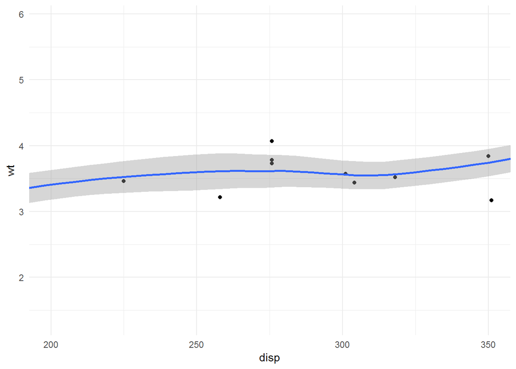

```r
p + coord_cartesian(xlim = c(200, 350))
```

### Salvestamine

Graafikute salvestamine. Esimene viis on faili printimine.

```r
#avame faili
png("myplot.png")
myplot <-ggplot(us_state_populations, aes(x=population_thousand))+
  geom_density(color="black", fill="lightblue", linetype="dashed")+
  theme_light()
#prindime faili
print(myplot)
#sulgeme faili
dev.off()
```

Teine viis on ggsave.

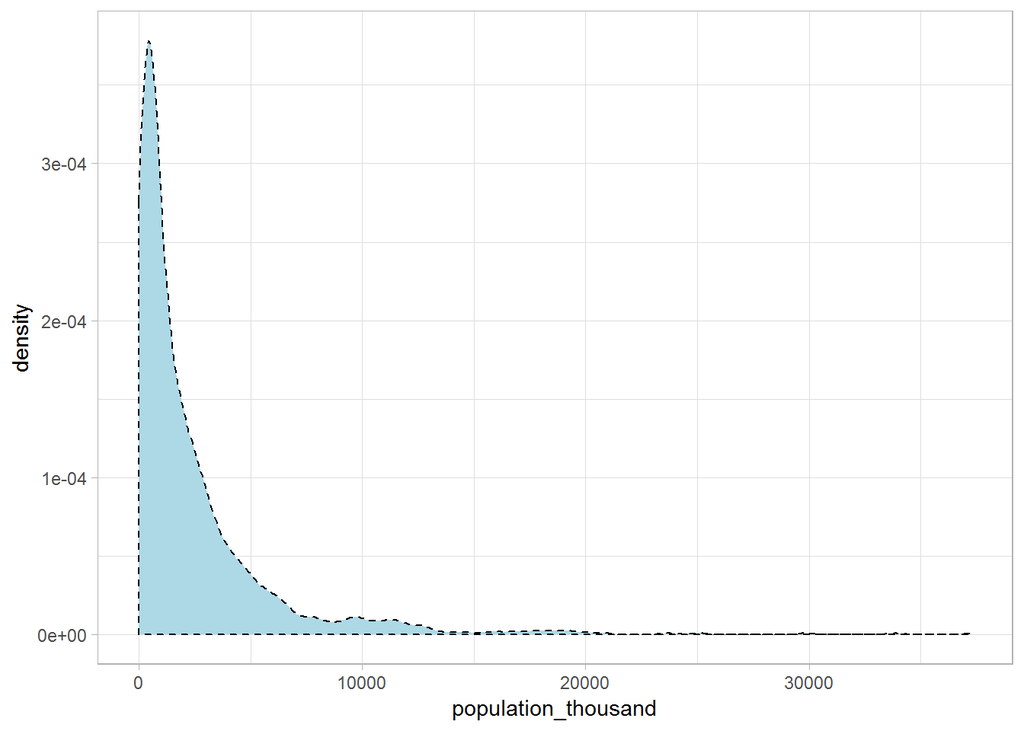

```r
ggplot(us_state_populations, aes(x=population_thousand))+
  geom_density(color="black", fill="lightblue", linetype="dashed")+
  theme_light()
```

```r
#salvestab välja prinditud ploti faili
ggsave("myplot.png", width = 4, height = 4)
```

## Ülesanne

Võta mõni endale oluline/huvitav andmehulk. Loe see sisse, anna esmane ülevaade (jaotused gruppide lõikes, keskmised jne). Lisaks visualiseeri neid ülevaateid kasutades ggploti.